# Data Analysis Assessment

Author

Milan Hilde-Jones

## Load Data

```r
#packages
library(tidyverse) # data wrangling and visualization
library(patchwork) # formatting plots
library(stats) # model building and selection (glm)
library(table1) # format base characteristics
library(sjPlot) # format regression results
library(sjmisc)
library(sjlabelled)
library(kableExtra)


# data
mbita_schisto <- read_rds("provided_files_data/mbita_schisto.rds")
mbita_spatial <- read_rds("provided_files_data/mbita_spatial.rds")
```

## Description

### Schistosomiasis Data

`mbita_schisto` consists of 3663 observations and 12 variables (9 numeric, 2 factor, and 1 character). Data were collected in 2012, 2013, and 2014. The study measured 1120 individuals at baseline, followed by 1187 in 2013, and 1356 in 2014. Mean age at time of measurement was 3.38 years, youngest age at time of measurement is 0.21 years, and oldest age at time of measurement is 5.55 years.

There are two identifier variables, `pid` and `vid`, representing child id and village id. `arm` is a factor with two levels (community-wide treatment, n = 1826; and school-based treatment, n = 1837). This variable describes the original arm of the study: community-wide treatment (CWT) versus school-based treatment (SBT). The sex of each child is listed under `sex`, with 1904 females and 1759 males.

`sm_epg` and `kk_pos` are both missing 237 values. These missing values occur in all three years, with missing data from 48 individuals in 2012, 15 in 2013, and 174 in 2014.

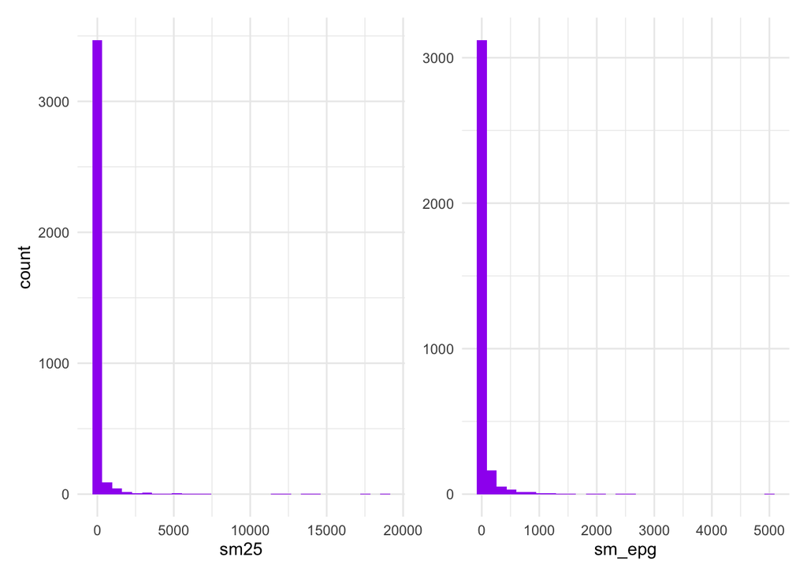

```r
# sm25
p1 <- ggplot(mbita_schisto) +
  geom_histogram(aes(sm25), fill = "purple") +
  theme_minimal()

# sm_epg
p2 <- ggplot(mbita_schisto) +
  geom_histogram(aes(sm_epg), fill = "purple") +
  labs(y = NULL) +
  theme_minimal()

p1 + p2
```

There are isolated extreme values in `sm25` and `sm_epg` that could impact results and might be explored as potential outliers.

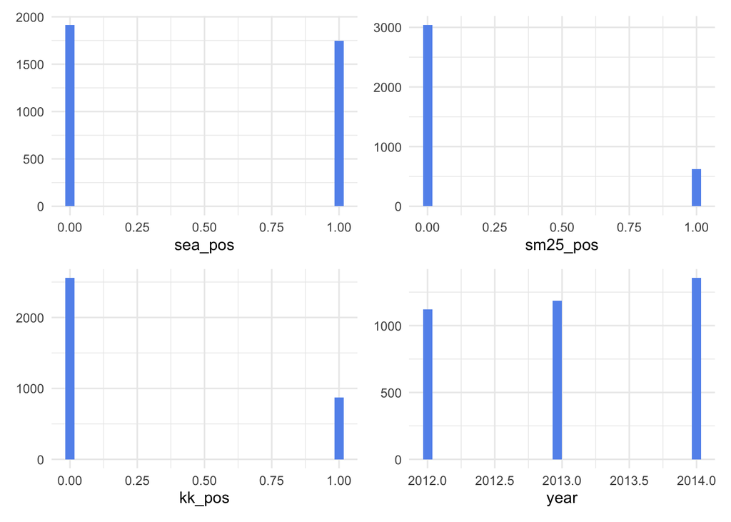

```r
p3 <- ggplot(mbita_schisto) +
  geom_histogram(aes(sea_pos), fill = "cornflowerblue") +
  labs(y = NULL) +
  theme_minimal()

p4 <- ggplot(mbita_schisto) +
  geom_histogram(aes(sm25_pos), fill = "cornflowerblue") +
  labs(y = NULL) +
  theme_minimal()

p5 <- ggplot(mbita_schisto) +
  labs(y = NULL) +
  geom_histogram(aes(kk_pos), fill = "cornflowerblue") +
  theme_minimal()


p6 <- ggplot(mbita_schisto) +
  geom_histogram(aes(year), fill = "cornflowerblue") +
  labs(y = NULL) +
  theme_minimal()




p3 + p4 + p5 + p6
```

As shown above, `sea_pos`, `sm25_pos`, `kk_pos`, and `year` contain only discrete values and should be converted into factors.

### Spatial Data

```r
# represents units var type as character
skimr::skim_without_charts(mbita_spatial)
```

Data summary

| Name | mbita_spatial |
| --- | --- |
| Number of rows | 30 |
| Number of columns | 5 |
| _______________________ |  |
| Column type frequency: |  |
| character | 1 |
| numeric | 4 |
| ________________________ |  |
| Group variables | None |

**Variable type: character**

| skim_variable | n_missing | complete_rate | min | max | empty | n_unique | whitespace |
| --- | --- | --- | --- | --- | --- | --- | --- |
| dist_victoria | 0 | 1 | 15 | 16 | 0 | 30 | 0 |

**Variable type: numeric**

| skim_variable | n_missing | complete_rate | mean | sd | p0 | p25 | p50 | p75 | p100 |
| --- | --- | --- | --- | --- | --- | --- | --- | --- | --- |
| vid | 0 | 1 | 15.50 | 8.80 | 1.00 | 8.25 | 15.50 | 22.75 | 30.00 |
| elev | 0 | 1 | 1175.50 | 44.82 | 1137.00 | 1151.50 | 1158.50 | 1184.75 | 1338.00 |
| tmin | 0 | 1 | 158.19 | 2.84 | 148.92 | 157.15 | 158.54 | 160.46 | 161.42 |
| prec | 0 | 1 | 89.37 | 6.43 | 81.17 | 83.46 | 89.58 | 94.62 | 101.42 |

```r
# vis dist_victoria seperately

# mean distance from lake victoria
mean(mbita_spatial$dist_victoria)
```

```
[1] 1187.034
```

```r
# max distance from lake victoria
max(mbita_spatial$dist_victoria)
```

```
[1] 4718.11
```

```r
# min distance from lake victoria
min(mbita_spatial$dist_victoria)
```

```
[1] 32.27604
```

`mbita_spatial` contains 30 observations and 5 variables. The unique identifier variable is `vid` (village id).

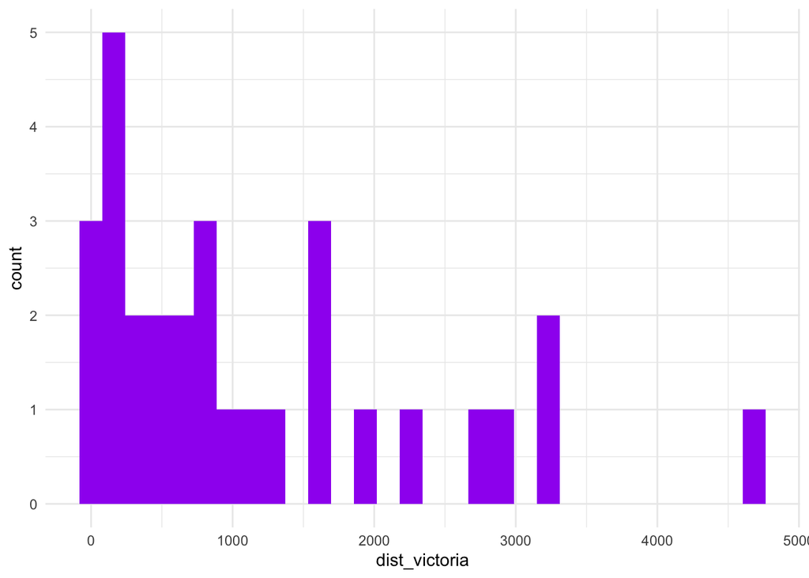

```r
# distance distribution
ggplot(mbita_spatial) +
  geom_histogram(aes(dist_victoria), fill = "purple") +
  theme_minimal()
```

```r
# top 5 highest elevation
mbita_spatial %>%
  select(vid, elev) %>%
  arrange(desc(elev)) %>%
  head(n = 5)
```

```
# A tibble: 5 × 2
    vid  elev
  <int> <dbl>
1    23  1338
2    17  1281
3    30  1256
4    20  1205
5    11  1199
```

```r
# top 5 furthest
mbita_spatial %>%
  select(vid, dist_victoria) %>%
  filter(dist_victoria[,1] > 2500) %>%
  arrange(desc(dist_victoria[,1]))
```

```
# A tibble: 5 × 2
    vid dist_victoria[,1]
  <int>             <dbl>
1    23             4718.
2    29             3309.
3    24             3240.
4    30             2829.
5    17             2752.
```

There don’t seem to be extreme values in `elev`, `tmin`, or `prec`. Village 23 is furthest from Lake Victoria (4718 vs. the mean at 1187 and second furthest at 3309). This village is also at the highest elevation (1338).

`tmin` reflects the average minimum temperature in each village, ranging from 149-161 (units not listed in codebook). A temperature within this range does not make sense on any of the three common scales. However, an average minimum temperature between 14.9 and 16.1°C is reasonable, so I scaled values to fit within this range.

## Data Processing

The following code chunk factors `sea_pos`, `sm25_pos`, `kk_pos`, `year`, and `vid`, re-scales `tmin`, and joins `mbita_schisto` with `mbita_spatial`. It also re-levels `arm` to code SBT as the first (reference) level.

```r
# turn sea_pos, sm25_pos, kk_pos, year, vid into factors
mbita_schisto_factor <- mbita_schisto %>%
  mutate(sea_pos = factor(sea_pos, levels = c(0, 1)),
         sm25_pos = factor(sm25_pos, levels = c(0, 1)),
         kk_pos = factor(kk_pos, levels = c(0, 1)),
         year = factor(year, levels = c(2012, 2013, 2014)),
         vid = factor(vid, levels = 1:30),
         # relevel so reference group is SBT
         arm = relevel(arm, "SBT")
         )

# factor vid, scale tmin
mbita_spatial_factor <- mbita_spatial %>%
  mutate(vid = factor(vid, levels = 1:30),
         # assume that tmin is coded wrong bc 150-160 doesn't make sense on F, C, or K
         # divide by 10 to make more sense in deg Celcius
         tmin = tmin/10
         )

# join datasets
joined_data <- left_join(mbita_schisto_factor, mbita_spatial_factor, by = "vid")
```

## Baseline Characteristics

```r
# variable labels
label(joined_data$year)    <- "Year"
label(joined_data$agey)   <- "Age"
label(joined_data$sex)   <- "Sex"
label(joined_data$sea) <- "SEA"
label(joined_data$sm25) <- "Sm25"
label(joined_data$sm_epg) <- "Sm EPG"
label(joined_data$sea_pos) <- "SEA positive"
label(joined_data$sm25_pos) <- "Sm25 positive"
label(joined_data$kk_pos) <- "Kato-Katz positive"
label(joined_data$elev) <- "Elevation"
label(joined_data$tmin) <- "Average minimum temperature"
label(joined_data$prec) <- "Average precipitation"
label(joined_data$dist_victoria) <- "Distance to lake Victoria"

# take out default units (m) for "Distance"
units(joined_data$dist_victoria) <- NULL

# title of table
title <- "Baseline Characteristics"

# table
table1(~ year + agey + sex + sea + sm25 +
         sm_epg + sea_pos + sm25_pos + kk_pos +
         elev + tmin + prec + dist_victoria |
         arm, data = joined_data, caption = title, overall = F)
```

Baseline Characteristics

|  | SBT (N=1837) | CWT (N=1826) |
| --- | --- | --- |
| Year |  |  |
| 2012 | 582 (31.7%) | 538 (29.5%) |
| 2013 | 624 (34.0%) | 563 (30.8%) |
| 2014 | 631 (34.3%) | 725 (39.7%) |
| Age |  |  |
| Mean (SD) | 3.37 (1.22) | 3.38 (1.21) |
| Median [Min, Max] | 3.50 [0.372, 5.54] | 3.50 [0.211, 5.55] |
| Sex |  |  |
| male | 868 (47.3%) | 891 (48.8%) |
| female | 969 (52.7%) | 935 (51.2%) |
| SEA |  |  |
| Mean (SD) | 13200 (13600) | 10800 (13300) |
| Median [Min, Max] | 4330 [4.00, 32700] | 228 [6.00, 32600] |
| Sm25 |  |  |
| Mean (SD) | 99.6 (510) | 159 (1020) |
| Median [Min, Max] | 6.00 [-12.0, 12300] | 5.00 [-7.00, 18800] |
| Sm EPG |  |  |
| Mean (SD) | 51.1 (225) | 32.8 (140) |
| Median [Min, Max] | 0 [0, 5000] | 0 [0, 1930] |
| Missing | 112 (6.1%) | 125 (6.8%) |
| SEA positive |  |  |
| 0 | 872 (47.5%) | 1042 (57.1%) |
| 1 | 965 (52.5%) | 784 (42.9%) |
| Sm25 positive |  |  |
| 0 | 1517 (82.6%) | 1523 (83.4%) |
| 1 | 320 (17.4%) | 303 (16.6%) |
| Kato-Katz positive |  |  |
| 0 | 1242 (67.6%) | 1315 (72.0%) |
| 1 | 483 (26.3%) | 386 (21.1%) |
| Missing | 112 (6.1%) | 125 (6.8%) |
| Elevation |  |  |
| Mean (SD) | 1170 (29.0) | 1170 (39.7) |
| Median [Min, Max] | 1160 [1140, 1280] | 1160 [1140, 1340] |
| Average minimum temperature |  |  |
| Mean (SD) | 15.9 (0.188) | 15.8 (0.276) |
| Median [Min, Max] | 15.9 [15.3, 16.1] | 15.9 [14.9, 16.1] |
| Average precipitation |  |  |
| Mean (SD) | 87.5 (5.29) | 89.5 (6.49) |
| Median [Min, Max] | 83.9 [81.5, 96.5] | 87.1 [81.2, 101] |
| Distance to lake Victoria |  |  |
| Mean (SD) | 936 (924) | 1090 (1090) |
| Median [Min, Max] | 713 [48.1, 3310] | 1050 [32.3, 4720] |

The total number of samples for SBT and CWT are approximately the same. The quantity of SBT samples are more balanced across years in comparison to CWT. The most noticeable imbalance between CWT and SBT observations is between 2013 and 2014, which does not affect the present analysis as post-treatment results are combined across years. The distributions of both sex and age are well balanced across treatment groups.

Spatial data (`elev`, `prec`, `tmin`,`dist_victoria`) look well balanced across trial groups.

## Compare *S.* *mansoni* Seroprevalence

Analysis was conducted with binomial logistic regression. Models compare the difference in prevalence ratio between villages that received community-wide treatment (CWT) versus school-based treatment (SBT). CWT was treated as the intervention group and SBT as the comparison group.

Prevalence was analyzed at the community level with the ratio of positive responses to total observations from 2013 and 2014 for each village. Model selection was performed separately for the soluble egg antigen (SEA) and recombinant antigenSm25 (Sm25) based tests.

```r
model_data <- joined_data %>%
  group_by(vid) %>%
  # seperate values from 2012 and 13+14
  mutate(sea_2012 = if_else(year == 2012, sea_pos, NA),
         sm25_2012 = if_else(year == 2012, sm25_pos, NA),
         # seperate test values from 2013
         sea_2013 = if_else(year == 2013, sea_pos, NA),
         sm25_2013 = if_else(year == 2013, sm25_pos, NA),
         # seperate test values from 2014
         sea_2014 = if_else(year == 2014, sea_pos, NA),
         sm25_2014 = if_else(year == 2014, sm25_pos, NA),
         # combined 13/14 results
         sea_2013_14 = if_else(year != 2012, sea_pos, NA),
         sm25_2013_14 = if_else(year != 2012, sm25_pos, NA),

         # want the ratio positive/total in 2013 and 2014 combined
         # need to find total obs for each year bc its different
         # counts sea
         sea_2012_count = sum(sea_2012 == "1" | sea_2012 == "0", na.rm=T),
         sea_2013_count = sum(sea_2013 == "1" | sea_2013 == "0", na.rm=T),
         sea_2014_count = sum(sea_2014 == "1" | sea_2014 == "0", na.rm=T),
         # counts sm24
         sm25_2012_count = sum(sm25_2012 == "1" | sm25_2012 == "0", na.rm=T),
         sm25_2013_count = sum(sm25_2013 == "1" | sm25_2013 == "0", na.rm=T),
         sm25_2014_count = sum(sm25_2014 == "1" | sm25_2014 == "0", na.rm=T),
         # total count obs in village
         # no NA in either sea or sm25 so will have the same total counts
         total_obs_2013_14 = sea_2013_count + sea_2014_count,

         # ratio positive/total in 2012
         sea_prop_2012 = sum(sea_2012 == "1", na.rm=T) / sea_2012_count,
         sm25_prop_2012 = sum(sm25_2012 == "1", na.rm=T) / sm25_2012_count,

         # combined proportion positives in 2013+14
         sea_avg_2013_14 = sum(sea_2013_14 == "1", na.rm=T) / total_obs_2013_14,
         sm25_avg_2013_14 = sum(sm25_2013_14 == "1", na.rm=T) / total_obs_2013_14,

         # compute avg village age
         avg_age = mean(agey),
         # m:f sex ratio of village
         sex_perc = sum(sex == "male", na.rm=T) / n(),
         # create a new temporary id variable for obs within each village
         temp_id = row_number()
  )%>%
  # remove all the extra variables I wont use in models
  select(-sea_2012, -sm25_2012, -sea_2013, -sm25_2013, -sea_2014, -sm25_2014,
         -sea_2013_14, -sm25_2013_14, -sea_2012_count, -sea_2013_count, -sea_2014_count,
         -sm25_2012_count, -sm25_2013_count, -sm25_2014_count,
         -sea, -sm25, -sm_epg, -sea_pos, -sm25_pos, -kk_pos,
         -pid, -agey, -sex, -year
         ) %>%
  # filter out all extraneous rows (all row w/in each village have same values)
  filter(temp_id == 1) %>%
  # now can remove temp id too
  select(-temp_id) %>%
  # ungroup
  ungroup(vid)
```

The SEA model accounted for the proportion of baseline positive SEA responses (from 2012), as well as the average minimum temperature, average precipitation, elevation, distance to Lake Victoria, average age, and male:female sex ratio for each village.

The Sm25 model also accounted for the proportion of baseline positive Sm25 responses, as well as the average age, average minimum temperature, average precipitation, elevation, distance to Lake Victoria, average age, and male:female sex ratio for each village.

```r
# sea model (kitchen sink)
sea_final_model <- glm(sea_avg_2013_14 ~ arm + sea_prop_2012 + tmin + prec +
                         dist_victoria + avg_age + elev + sex_perc,
                       data = model_data,
                       family = binomial,
                       weights = total_obs_2013_14
)

# sm25 model (kitchen sink)
sm25_final_model <-  glm(sm25_avg_2013_14 ~ arm + sm25_prop_2012 + tmin + prec +
                           dist_victoria + avg_age + elev + sex_perc,
                         data = model_data,
                         family = binomial,
                         weights = total_obs_2013_14
)


# Build formatted results table

# define labels
pred_labels <- c("arm CWT", "SEA prevalence ratio in 2012",
                 "Average minimum temperature", "Average precipitation",
                 "Distance to lake Victoria", "Average age", "Elevation",
                 "Sex ratio (male:female)", "Sm25 prevalence ratio in 2012")

dv_labels <- c("SEA", "Sm25" )


# build table
tab_model(sea_final_model, sm25_final_model,
          title = "Regression Results",
          show.intercept = FALSE,
          pred.labels = pred_labels,
          dv.labels = dv_labels,
          string.est = "Odds Ratio",
          string.ci = "95% CI")
```

Regression Results

|  | SEA |  |  | Sm25 |  |  |
| --- | --- | --- | --- | --- | --- | --- |
| Predictors | Odds Ratio | 95% CI | p | Odds Ratio | 95% CI | p |
| arm CWT | 1.03 | 0.86 – 1.24 | 0.750 | 1.11 | 0.89 – 1.38 | 0.343 |
| SEA prevalence ratio in 2012 | 19.06 | 10.13 – 36.20 | **<0.001** |  |  |  |
| Average minimum temperature | 0.00 | 0.00 – 0.02 | **<0.001** | 0.20 | 0.02 – 2.10 | 0.184 |
| Average precipitation | 0.81 | 0.77 – 0.86 | **<0.001** | 0.94 | 0.87 – 1.00 | **0.050** |
| Distance to lake Victoria | 1.00 | 1.00 – 1.00 | 0.149 | 1.00 | 1.00 – 1.00 | 0.263 |
| Average age | 3.55 | 1.51 – 8.39 | **0.004** | 0.22 | 0.08 – 0.58 | **0.002** |
| Elevation | 0.98 | 0.97 – 0.99 | **<0.001** | 0.99 | 0.98 – 1.00 | 0.191 |
| Sex ratio (male:female) | 0.50 | 0.06 – 4.08 | 0.521 | 0.07 | 0.01 – 0.75 | **0.027** |
| Sm25 prevalence ratio in 2012 |  |  |  | 7.39 | 3.26 – 16.81 | **<0.001** |
| Observations | 30 |  |  | 30 |  |  |

### Discussion

`arm` was treated as an indicator variable with SBT as the reference group. Thus, the estimate for armCWT represents the average difference in CWT compared to SBT, after accounting for other variables.

There is no significant difference in prevalence between SBT and CWT groups for either model at a p<0.05 level. Results provide little evidence that CWT influences the likelihood of a positive SEA or Sm25 response relative to SBT across the post-treatment period.

## Permutation Tests

```r
# SEA ----------------------------------------------------------------------------------------

# calculate difference in means of observed data
orig_diff_sea <- mean(model_data$sea_avg_2013_14[model_data$arm == "CWT"]) -
  mean(model_data$sea_avg_2013_14[model_data$arm == "SBT"])


# number of observations
n <- length(model_data$arm)
# number of permutation samples
p <- 10000
# outcome variable of interest
outcome_sea <- model_data$sea_avg_2013_14


# create matrix to hold permutation sets
p_samples_sea  <- matrix(0, nrow = n, ncol = p)


# for loop to iterate through and fill matrix
set.seed(3013)
for (i in 1:p) {
  # replace 0s in column i w/ samples
  p_samples_sea[,i] <- sample(outcome_sea, size = n, replace = FALSE)
}


# vector to store difference in means for each permutation set
test_stats_sea <- rep(0, 10000)

# calculate test stats for each and store
for(i in 1:p) {
  # abs value of diff btwn SBT and CWT means for each permutation
  test_stats_sea[i] <-
    mean(p_samples_sea[model_data$arm =="SBT", i]) - mean(p_samples_sea[model_data$arm=="CWT", i])
}

# calculate p-value
p_sea <- mean(abs(test_stats_sea) >= abs(orig_diff_sea)) # 0.3882



# Sm25 ----------------------------------------------------------------------------------------


orig_diff_sm25 <- mean(model_data$sm25_avg_2013_14[model_data$arm == "CWT"]) -
  mean(model_data$sm25_avg_2013_14[model_data$arm == "SBT"])



# number of observations
n <- length(model_data$arm)
# number of permutation samples
p <- 10000
# outcome variable of interest
outcome_sm25 <- model_data$sm25_avg_2013_14


# matrix to hold permutation sets
p_samples_sm25  <- matrix(0, nrow = n, ncol = p)


set.seed(3013)
for (i in 1:p) {
  p_samples_sm25[,i] <- sample(outcome_sm25, size = n, replace = FALSE)
}



# vector to store for each permutation
test_stats_sm25 <- rep(0, 10000)

# calculate difference in means for each and store
for(i in 1:p) {
  test_stats_sm25[i] <-
    mean(p_samples_sm25[model_data$arm =="SBT", i]) -
    mean(p_samples_sm25[model_data$arm=="CWT", i])
}

# calculate p
p_sm25 <- mean(abs(test_stats_sm25) >= abs(orig_diff_sm25)) # 0.8214


# format results in a tibble
tibble(
  "Test type" = c("SEA", "Sm25"),
  "Permutation P-value" = c(p_sea, p_sm25)
) %>%
  kbl() %>%
  kable_styling()
```

| Test type | Permutation P-value |
| --- | --- |
| SEA | 0.3882 |
| Sm25 | 0.8214 |

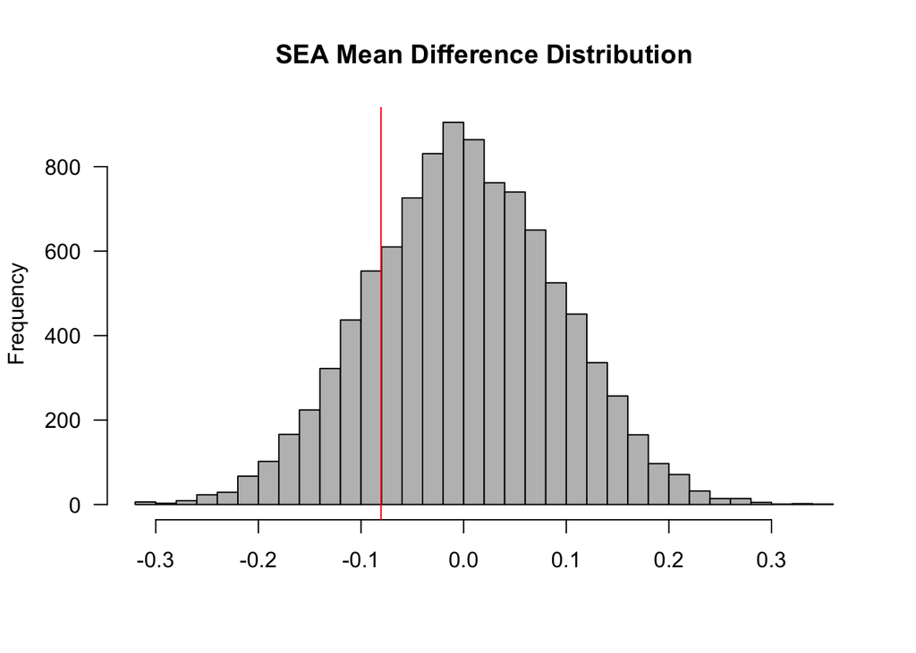

```r
# plot distributions

hist(test_stats_sea, breaks = 30, col='grey', las = 1,
     main = "SEA Mean Difference Distribution", xlab = '')
abline(v = orig_diff_sea, col="red")
```

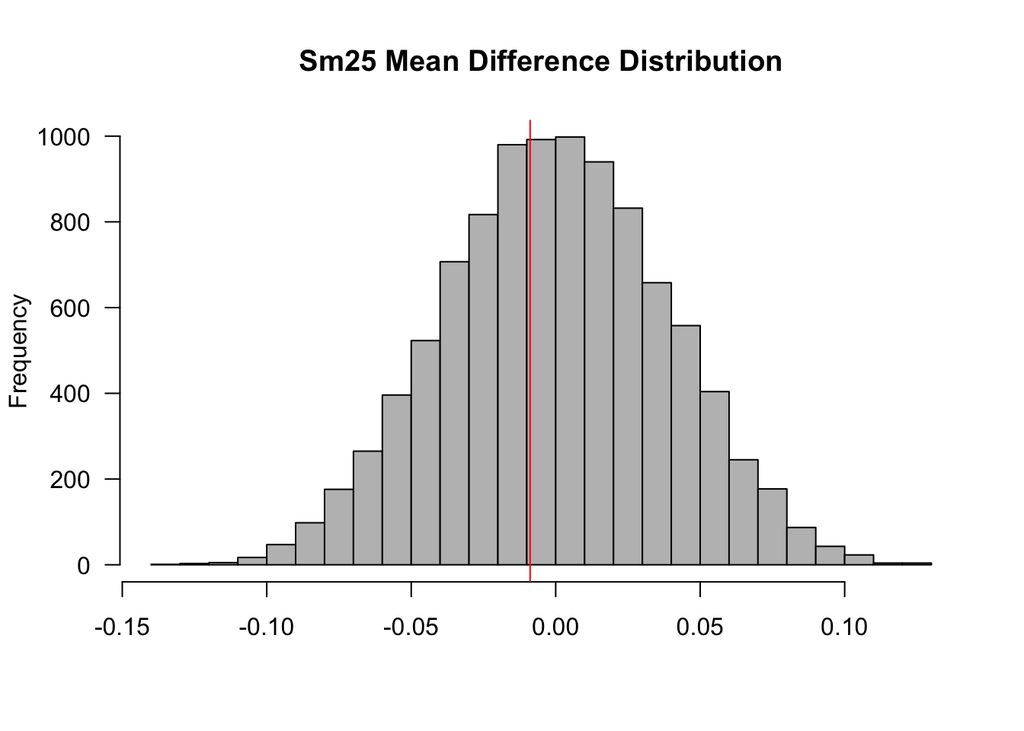

```r
hist(test_stats_sm25, breaks = 30, col='grey', las = 1,
     main = "Sm25 Mean Difference Distribution", xlab = '')
abline(v = orig_diff_sm25, col="red")
```